# FIA - NLS Models: Biomass Growth vs. Stand Age, Temporally-Balanced, No Harvest

JAH

2022-10-25

# Background

This document has nls (non-linear least squares) regression fits using the lognormal functional form to USFS FIA (United States Forest Service Forest Inventory & Analysis) **biomass growth vs. stand age** relationships. This functional form is commonly used in growth analyses, and permits a flexible shape to fit to data in an intermediate maximum (i.e., “hump” shaped) relationship. We use the sum of tree biomass growth increment method for the plot biomass growth ($G$) calculation (see supplementary methods). Models are fitted separately by US ecoprovince.

Data have increasing variance in $G$ with increasing $StdAge_{t1}$, Thus, weighted nls is the best approach. We explore a few weighting options and found that proportional weighting can be achieved by weighting observations by $\frac {1} {meanG}$ in equal-sample sized plot biomass bins (n=20) for each ecoprovince.

Model selection is used to determine. to determine the best fitting models, which is implemented in two parts. A first model selection is done to determine the best model form either including $\alpha$: the biomass compensation effect due to lost biomass (natural mortality or harvest), $\phi$: the effect of changing climate (quantified as $\Delta PDSI$, or both. $\Delta PDSI$ is defined the difference in the Palmer drought severity index from January - August for the 10 years preceding the biomass measurement and the 1969-1990 period). We explored $\Delta PDSI$ using only the summer growing months (June-August) over the same intervals, and analyses were insensitive to that change. For the first model selection the following models are considered:

**model 1: simple model** $G = (1 + (yr-1990) \cdot ge/100) \times \left(a + b \cdot \exp{ - \left[ \frac{ \log \left( StdAge_{t1} /c \right)} {d} \right]} ^2 \right)$

**model 2: phi model** $G = (1 + (yr-1990) \cdot ge/100) \times (1 + \phi \cdot \Delta PDSI) \times \left(a + b \cdot \exp{ - \left[ \frac{ \log \left( StdAge_{t1} /c \right)} {d} \right]} ^2 \right)$

**model 3: phi-alpha model** $G = (1 + (yr-1990) \cdot ge/100) \times (1 + \phi \cdot \Delta PDSI) \times (1 - \alpha \cdot B_l) \times \left(a + b \cdot \exp{ - \left[ \frac{ \log \left( StdAge_{t1} /c \right)} {d} \right]} ^2 \right)$

*Note:*

*This analysis only uses plot biomass data from the same plot locations and measurement intervals for which we also have data on biomass growth (which is used in the* **growth vs. biomass analysis** *). We use the second of the two plot measurements comprising a $G$ interval*

*This analysis further excludes plots were timber harvest occurred*

This includes the following plot-based filtering criteria (which were used for the **growth vs. biomass analysis**):

1. exclude FIA plots in plantation forests
2. exclude FIA plots with multiple plot conditions (COND_PROG_UNADJ > 0.95)
3. exclude FIA plots non-productive stands (i.e., those with less than 20 ft^3/acre/year timber producing capability; SITECLCD of 7)
4. exclude FIA plots in non-stocked stands (i.e., those with STDSZCD of 5)
5. exclude FIA plots in non-accessible areas (i.e., private lands etc., COND_STATUS_CD not equal to 1)
6. exclude FIA plot visits that are not part of the annual inventories (which also includes FIA plot visits for Phase 3 ozone measurements)

Additionally, in an effort to clean up the data set, we have removed outlier observations, using a quantile threshold approach. We also calculated plot $G$ using as biomass balance method (see supplementary methods), and the difference between the two methods. Accordingly, we define $diff_G$ as the difference between tree incremental $G$ and biomass balance $G$. We excluded observations which meet the following criteria using a 0.5% quantile ($QT$):

- case A: where the $QT$ difference in tree incremental $G$ is > biomass balance plot G (i.e., > 99.5% $diff_G$ positive outliers)
- case B: where the $QT$ difference in tree incremental $G$ is < mass balance plot G (i.e., < 0.5% $diff_G$ negative outliers)
- case C: where the $QT$ difference in tree incremental $G$ is > 0 (i.e., > 99.5% positive outliers)
- case D: where the $QT$ difference in tree incremental $G$ is > 0 (i.e., < 0.5% negative outliers)

These data set cleaning criteria resulted in the exclusion of 1677 observations.

Below the model fitting procedure is implemented by ecoprovince:

# Temporally-balancing the biomass growth data set

Lets look at some quick attributes of the dataset

- The data set has 104986 observations, comprised of 55492 plots.
- The frequency of growth measurements among plots is as follows : 25149, 13819, 13897, 2627.
- Thus 54.68 % of plots have at least two growth intervals.

# 211 - Northeastern Mixed Forest

## model selection 1

```
## Error in nls(fg2_1, data = G_211, start = c(ge = ge.start2, a = a.start2,  :
##   singular gradient
## Error in nls(fg2_2, data = G_211, start = c(ge = ge.start2, phi = phi.start2,  :
##   singular gradient
## Error in nls(fg2_3, data = G_211, start = c(ge = ge.start2, phi = phi.start2,  :
##   step factor 0.000488281 reduced below 'minFactor' of 0.000976562
##   model AIC
## 1     1  NA
## 2     2  NA
## 3     3  NA
```

```
## Error in get(paste("nls_211.", Mod.Sel1, sep = "")) :
##   object 'nls_211.' not found
```

### summary

- simple model: does not fit
- phi model: does not fit
- phi-alpha model: does not fit

## plot residuals

```
## [1] "cannot plot residuals"
```

## predict and plot

```
## [1] "cannot plot data with prediction"
```

## plotting 2

# 212 - Laurentian Mixed Forest

## model selection 1

```
## Analysis of Variance Table
##
## Model 1: G_obs_TreeInc_MgHaYr ~ (1 + (MEASTIME_avg - 1990) * ge/100) * (a + b * exp(-((log(STDAGE_t1/c))/d)^2))
## Model 2: G_obs_TreeInc_MgHaYr ~ (1 + (MEASTIME_avg - 1990) * ge/100) * (1 + phi * DeltaPDSI) * (a + b * exp(-((log(STDAGE_t1/c))/d)^2))
## Model 3: G_obs_TreeInc_MgHaYr ~ (1 + (MEASTIME_avg - 1990) * ge/100) * (1 + phi * DeltaPDSI) * (1 - alpha * B_L_prop) * (a + b * exp(-((log(STDAGE_t1/c))/d)^2))
##   Res.Df Res.Sum Sq Df  Sum Sq F value    Pr(>F)
## 1   9634     8025.2
## 2   9631     7989.9  3  35.267   14.17 3.269e-09 ***
## 3   9630     7814.2  1 175.714  216.54 < 2.2e-16 ***
## ---
## Signif. codes:  0 '***' 0.001 '**' 0.01 '*' 0.05 '.' 0.1 ' ' 1
##   model      AIC
## 1     1 33766.05
## 2     2 33720.60
## 3     3 33508.29
```

```
##
## Formula: G_obs_TreeInc_MgHaYr ~ (1 + (MEASTIME_avg - 1990) * ge/100) *
##     (1 + phi * DeltaPDSI) * (1 - alpha * B_L_prop) * (a + b *
##     exp(-((log(STDAGE_t1/c))/d)^2))
##
## Parameters:
##        Estimate Std. Error t value Pr(>|t|)
## ge     0.875558   0.179837   4.869 1.14e-06 ***
## phi    0.028719   0.004313   6.659 2.91e-11 ***
## alpha  0.727344   0.046601  15.608  < 2e-16 ***
## a      0.853003   0.292817   2.913  0.00359 **
## b      1.711809   0.281820   6.074 1.29e-09 ***
## c     20.003747   0.954122  20.966  < 2e-16 ***
## d      2.040746   0.279592   7.299 3.13e-13 ***
## ---
## Signif. codes:  0 '***' 0.001 '**' 0.01 '*' 0.05 '.' 0.1 ' ' 1
##
## Residual standard error: 0.9008 on 9630 degrees of freedom
##
## Number of iterations to convergence: 8
## Achieved convergence tolerance: 4.341e-06
##   (21 observations deleted due to missingness)
```

### summary

- simple model: fits
- phi model: fits
- phi-alpha model: fits

## plot residuals

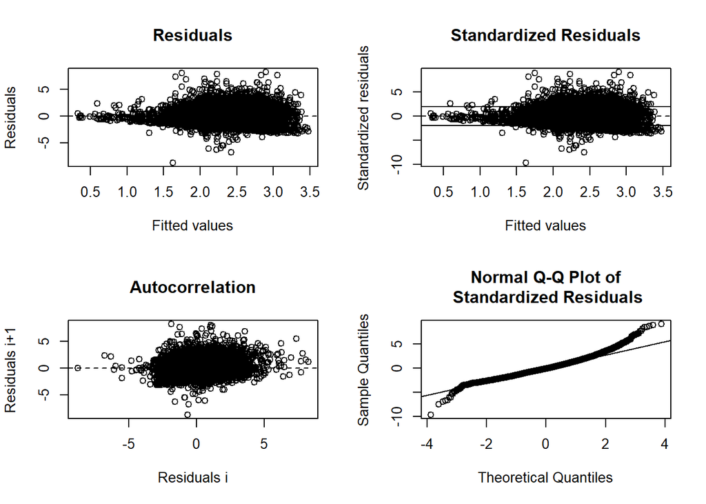

## predict and plot

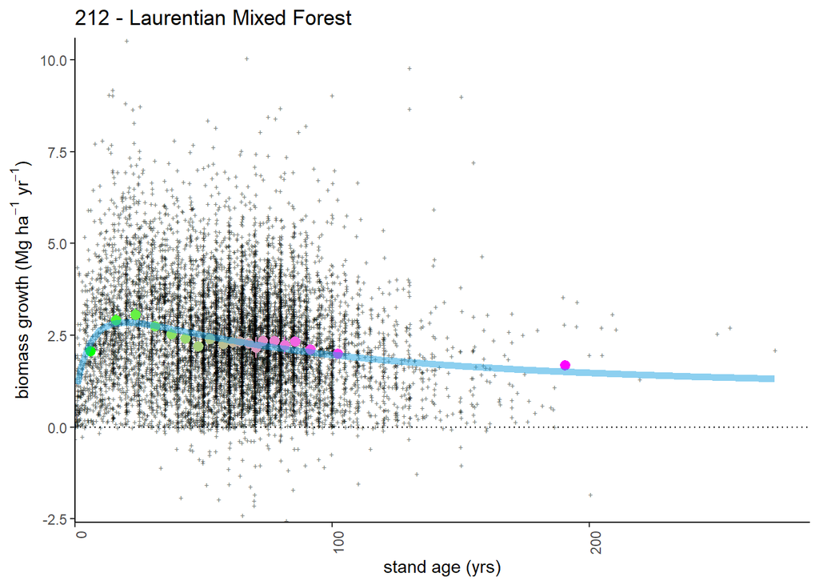

## plotting 2

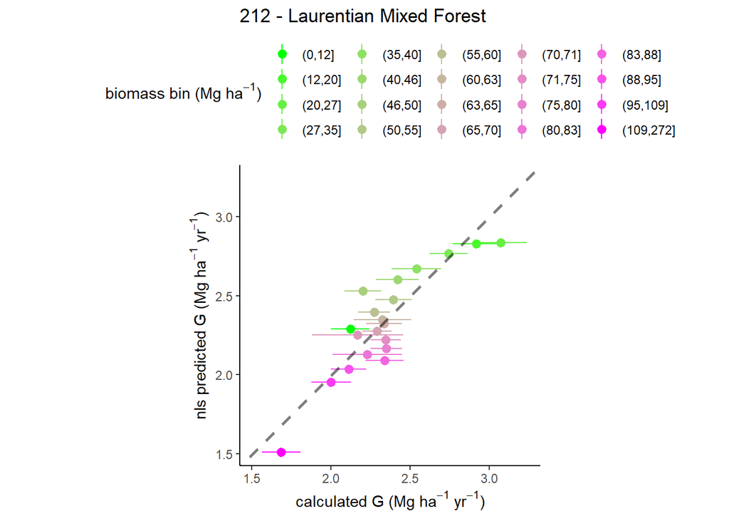

# 221 - Eastern Broadleaf Forest

## model selection 1

```
## Error in numericDeriv(form[[3L]], names(ind), env, central = nDcentral) :
##   Missing value or an infinity produced when evaluating the model
## Error in numericDeriv(form[[3L]], names(ind), env, central = nDcentral) :
##   Missing value or an infinity produced when evaluating the model
## Error in numericDeriv(form[[3L]], names(ind), env, central = nDcentral) :
##   Missing value or an infinity produced when evaluating the model
##   model AIC
## 1     1  NA
## 2     2  NA
## 3     3  NA
```

```
## Error in h(simpleError(msg, call)) :
##   error in evaluating the argument 'object' in selecting a method for function 'summary': object 'nls_221.' not found
```

### summary

- simple model: does not fit
- phi model: does not fit
- phi-alpha model: does not fit

## plot residuals

```
## [1] "cannot plot residuals"
```

## predict and plot

```
## [1] "cannot plot data with prediction"
```

## plotting 2

# 222 - Midwest Broadleaf Forest

## model selection 1

```
## Error in numericDeriv(form[[3L]], names(ind), env, central = nDcentral) :
##   Missing value or an infinity produced when evaluating the model
```

```
## Error in numericDeriv(form[[3L]], names(ind), env, central = nDcentral) :
##   Missing value or an infinity produced when evaluating the model
## Error in nls(fg2_3, data = G_222, start = c(ge = ge.start, phi = phi.start,  :
##   singular gradient
##   model AIC
## 1     1  NA
## 2     2  NA
## 3     3  NA
```

```
## Error in h(simpleError(msg, call)) :
##   error in evaluating the argument 'object' in selecting a method for function 'summary': object 'nls_222.' not found
```

### summary

- simple model: does not fit
- phi model: does not fit
- phi-alpha model: does not fit

## plot residuals

```
## [1] "cannot plot residuals"
```

## predict and plot

```
## [1] "cannot plot data with prediction"
```

## plotting 2

# 223 - Central Interior Broadleaf Forest

## model selection 1

```
## Analysis of Variance Table
##
## Model 1: G_obs_TreeInc_MgHaYr ~ (1 + (MEASTIME_avg - 1990) * ge/100) * (a + b * exp(-((log(STDAGE_t1/c))/d)^2))
## Model 2: G_obs_TreeInc_MgHaYr ~ (1 + (MEASTIME_avg - 1990) * ge/100) * (1 + phi * DeltaPDSI) * (a + b * exp(-((log(STDAGE_t1/c))/d)^2))
## Model 3: G_obs_TreeInc_MgHaYr ~ (1 + (MEASTIME_avg - 1990) * ge/100) * (1 + phi * DeltaPDSI) * (1 - alpha * B_L_prop) * (a + b * exp(-((log(STDAGE_t1/c))/d)^2))
##   Res.Df Res.Sum Sq Df Sum Sq F value   Pr(>F)
## 1   5014     5450.0
## 2   5013     5448.0  1  1.932  1.7781   0.1824
## 3   5010     5393.3  3 54.702 16.9381 6.06e-11 ***
## ---
## Signif. codes:  0 '***' 0.001 '**' 0.01 '*' 0.05 '.' 0.1 ' ' 1
##   model      AIC
## 1     1 20333.55
## 2     2 20333.77
## 3     3 20279.04
```

```
##
## Formula: G_obs_TreeInc_MgHaYr ~ (1 + (MEASTIME_avg - 1990) * ge/100) *
##     (1 + phi * DeltaPDSI) * (1 - alpha * B_L_prop) * (a + b *
##     exp(-((log(STDAGE_t1/c))/d)^2))
##
## Parameters:
##       Estimate Std. Error t value Pr(>|t|)
## ge    -1.06477    0.12555  -8.481  < 2e-16 ***
## phi   -0.01067    0.00818  -1.304 0.192265
## alpha  0.56711    0.08014   7.076 1.69e-12 ***
## a      2.88230    0.49259   5.851 5.19e-09 ***
## b      1.69285    0.47531   3.562 0.000372 ***
## c     29.62230    2.46153  12.034  < 2e-16 ***
## d      1.26981    0.32837   3.867 0.000112 ***
## ---
## Signif. codes:  0 '***' 0.001 '**' 0.01 '*' 0.05 '.' 0.1 ' ' 1
##
## Residual standard error: 1.038 on 5010 degrees of freedom
##
## Number of iterations to convergence: 8
## Achieved convergence tolerance: 7.397e-06
##   (7 observations deleted due to missingness)
```

### summary

- simple model: fits
- phi model: fits
- phi-alpha model: fits

## plot residuals

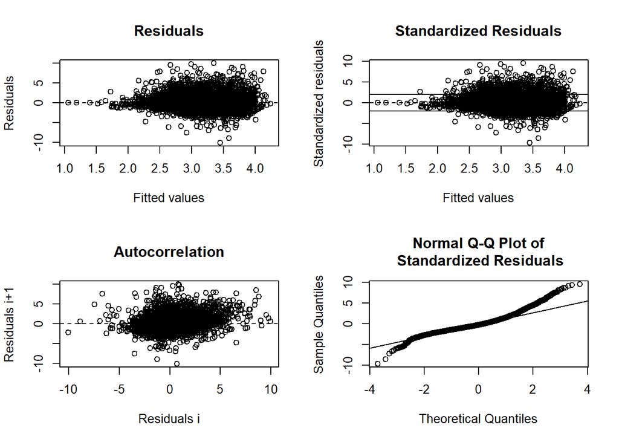

## predict and plot

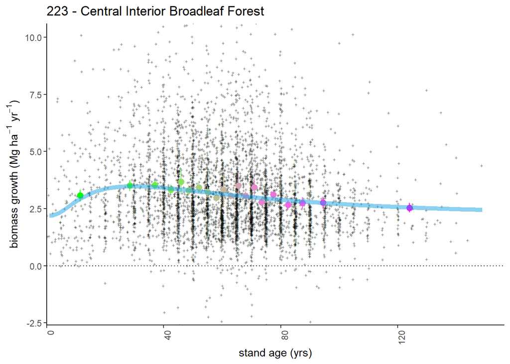

## plotting 2

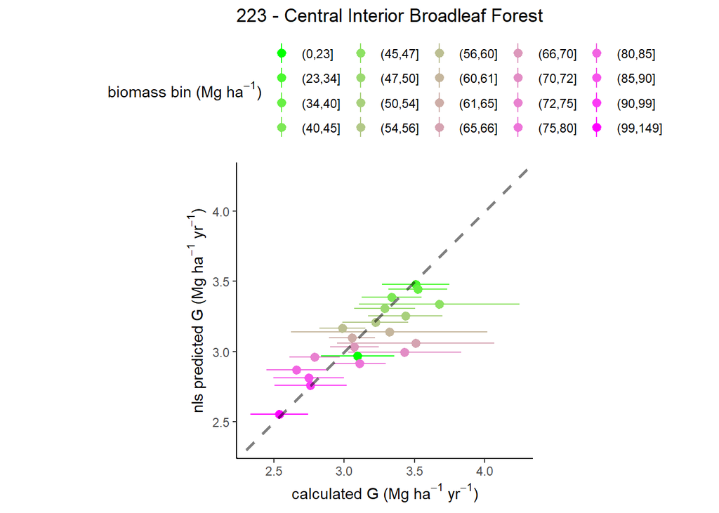

# 231 - Southeastern Mixed Forest

## model selection 1

```
## Analysis of Variance Table
##
## Model 1: G_obs_TreeInc_MgHaYr ~ (1 + (MEASTIME_avg - 1990) * ge/100) * (a + b * exp(-((log(STDAGE_t1/c))/d)^2))
## Model 2: G_obs_TreeInc_MgHaYr ~ (1 + (MEASTIME_avg - 1990) * ge/100) * (1 + phi * DeltaPDSI) * (a + b * exp(-((log(STDAGE_t1/c))/d)^2))
## Model 3: G_obs_TreeInc_MgHaYr ~ (1 + (MEASTIME_avg - 1990) * ge/100) * (1 + phi * DeltaPDSI) * (1 - alpha * B_L_prop) * (a + b * exp(-((log(STDAGE_t1/c))/d)^2))
##   Res.Df Res.Sum Sq Df  Sum Sq  F value Pr(>F)
## 1   5931     9514.9
## 2   5930     9514.8  1   0.035   0.0219 0.8824
## 3   5929     9279.3  1 235.568 150.5167 <2e-16 ***
## ---
## Signif. codes:  0 '***' 0.001 '**' 0.01 '*' 0.05 '.' 0.1 ' ' 1
##   model      AIC
## 1     1 28865.27
## 2     2 28867.25
## 3     3 28720.43
```

```
##
## Formula: G_obs_TreeInc_MgHaYr ~ (1 + (MEASTIME_avg - 1990) * ge/100) *
##     (1 + phi * DeltaPDSI) * (1 - alpha * B_L_prop) * (a + b *
##     exp(-((log(STDAGE_t1/c))/d)^2))
##
## Parameters:
##        Estimate Std. Error t value Pr(>|t|)
## ge    -0.261579   0.122762  -2.131   0.0331 *
## phi   -0.001744   0.005777  -0.302   0.7628
## alpha  0.839396   0.064923  12.929  < 2e-16 ***
## a      3.052539   0.392565   7.776 8.78e-15 ***
## b      3.523361   0.370681   9.505  < 2e-16 ***
## c     18.886646   0.645475  29.260  < 2e-16 ***
## d      1.462832   0.150467   9.722  < 2e-16 ***
## ---
## Signif. codes:  0 '***' 0.001 '**' 0.01 '*' 0.05 '.' 0.1 ' ' 1
##
## Residual standard error: 1.251 on 5929 degrees of freedom
##
## Number of iterations to convergence: 12
## Achieved convergence tolerance: 6.081e-06
##   (16 observations deleted due to missingness)
```

### summary

- simple model: fits
- phi model: fits
- phi-alpha model: fits

## plot residuals

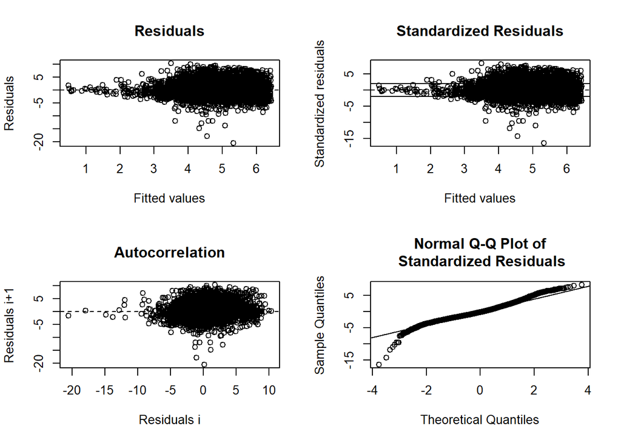

## predict and plot

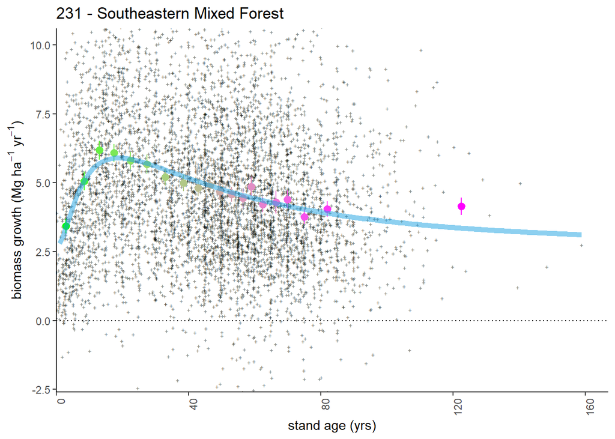

## plotting 2

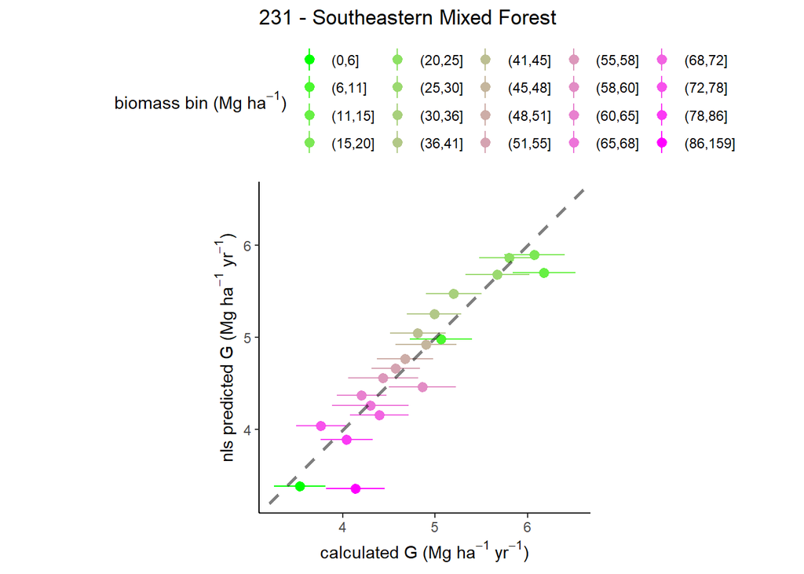

# 232 - Outer Coastal Plain Mixed Forest

## model selection 1

```
## Analysis of Variance Table
##
## Model 1: G_obs_TreeInc_MgHaYr ~ (1 + (MEASTIME_avg - 1990) * ge/100) * (a + b * exp(-((log(STDAGE_t1/c))/d)^2))
## Model 2: G_obs_TreeInc_MgHaYr ~ (1 + (MEASTIME_avg - 1990) * ge/100) * (1 + phi * DeltaPDSI) * (a + b * exp(-((log(STDAGE_t1/c))/d)^2))
## Model 3: G_obs_TreeInc_MgHaYr ~ (1 + (MEASTIME_avg - 1990) * ge/100) * (1 + phi * DeltaPDSI) * (1 - alpha * B_L_prop) * (a + b * exp(-((log(STDAGE_t1/c))/d)^2))
##   Res.Df Res.Sum Sq Df Sum Sq  F value Pr(>F)
## 1   6083      12734
## 2   6082      12733  1   0.45   0.2129 0.6445
## 3   6081      12392  1 341.61 167.6386 <2e-16 ***
## ---
## Signif. codes:  0 '***' 0.001 '**' 0.01 '*' 0.05 '.' 0.1 ' ' 1
##   model      AIC
## 1     1 30340.21
## 2     2 30342.00
## 3     3 30178.44
```

```
##
## Formula: G_obs_TreeInc_MgHaYr ~ (1 + (MEASTIME_avg - 1990) * ge/100) *
##     (1 + phi * DeltaPDSI) * (1 - alpha * B_L_prop) * (a + b *
##     exp(-((log(STDAGE_t1/c))/d)^2))
##
## Parameters:
##        Estimate Std. Error t value Pr(>|t|)
## ge     0.136505   0.178763   0.764    0.445
## phi   -0.001616   0.006491  -0.249    0.803
## alpha  0.806337   0.058445  13.796   <2e-16 ***
## a      3.445374   0.170389  20.221   <2e-16 ***
## b      2.288237   0.150754  15.179   <2e-16 ***
## c     16.638887   0.698299  23.828   <2e-16 ***
## d      0.947773   0.084159  11.262   <2e-16 ***
## ---
## Signif. codes:  0 '***' 0.001 '**' 0.01 '*' 0.05 '.' 0.1 ' ' 1
##
## Residual standard error: 1.427 on 6081 degrees of freedom
##
## Number of iterations to convergence: 8
## Achieved convergence tolerance: 9.88e-06
##   (32 observations deleted due to missingness)
```

### summary

- simple model: fits
- phi model: fits
- phi-alpha model: fits

## plot residuals

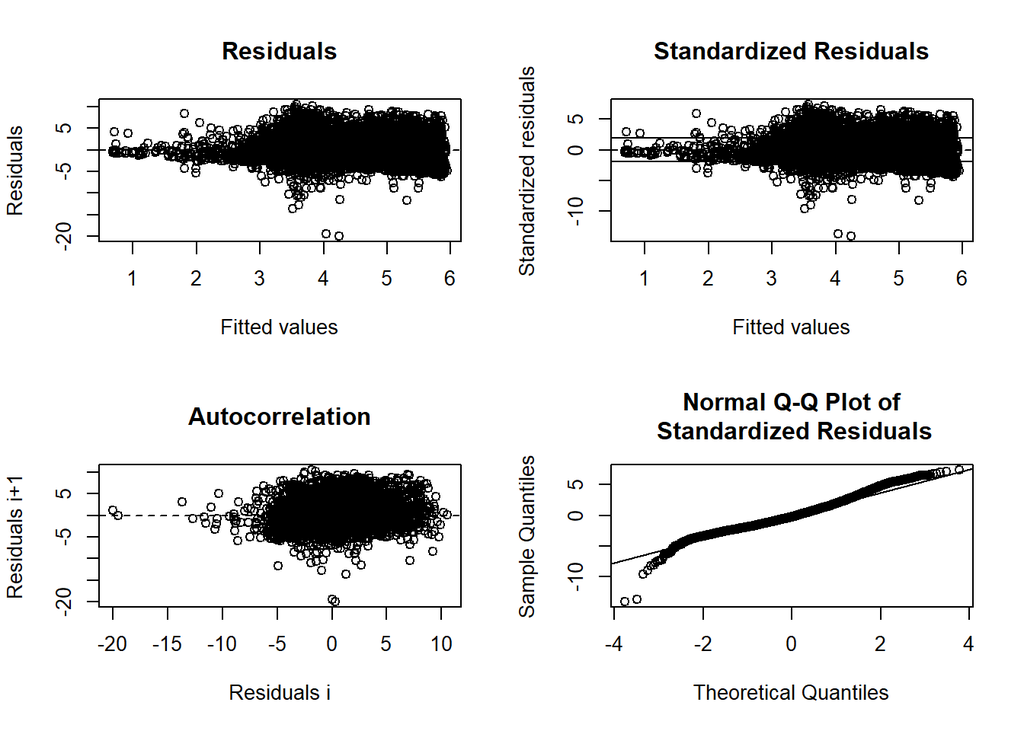

## predict and plot

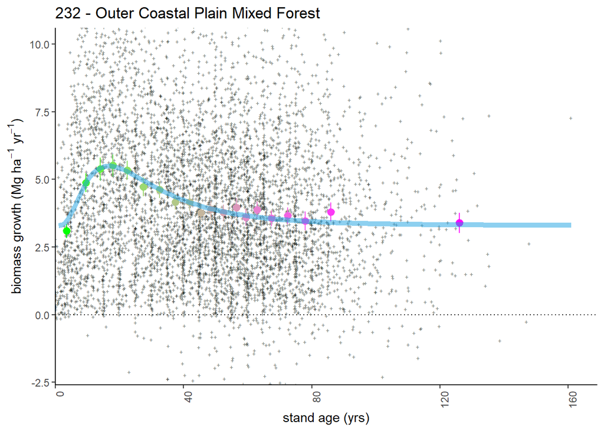

## plotting 2

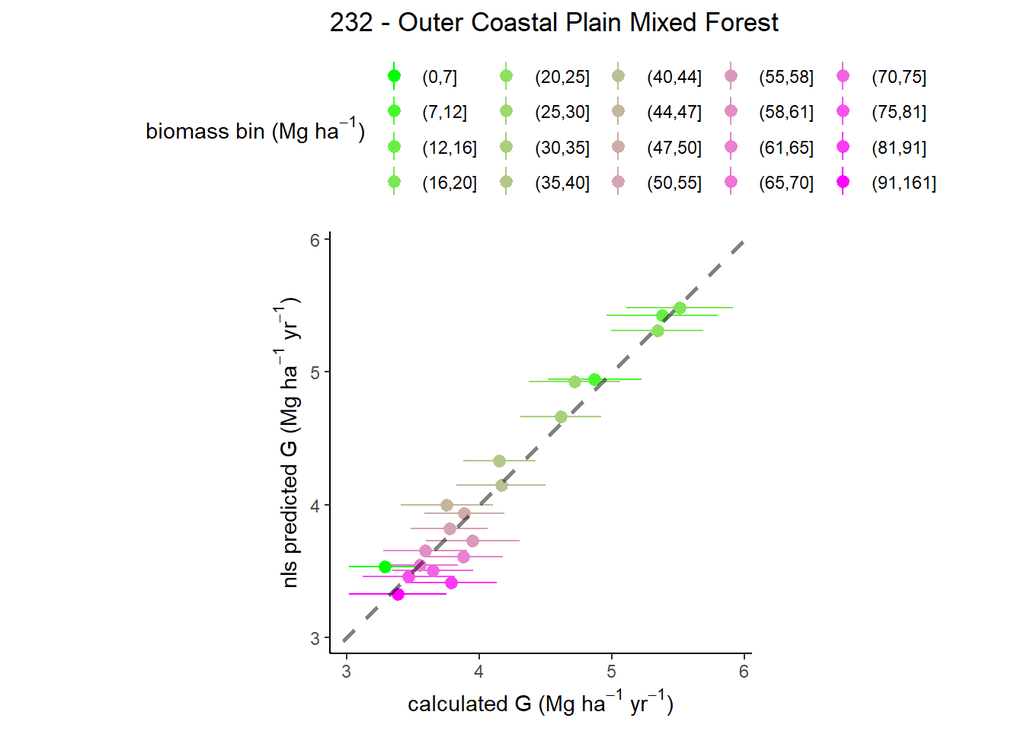

# 234 - Lower Mississippi Riverine Forest

## model selection 1

```
## Error in nls(fg2_2, data = G_234, start = c(ge = ge.start, phi = phi.start,  :
##   step factor 0.000488281 reduced below 'minFactor' of 0.000976562
##   model      AIC
## 1     1 3198.940
## 2     2       NA
## 3     3 3178.046
```

```
##
## Formula: G_obs_TreeInc_MgHaYr ~ (1 + (MEASTIME_avg - 1990) * ge/100) *
##     (1 + phi * DeltaPDSI) * (1 - alpha * B_L_prop) * (a + b *
##     exp(-((log(STDAGE_t1/c))/d)^2))
##
## Parameters:
##       Estimate Std. Error t value Pr(>|t|)
## ge    -0.09924    0.76516  -0.130 0.896844
## phi    0.01787    0.02997   0.596 0.551151
## alpha  0.93035    0.17062   5.453 7.12e-08 ***
## a      3.71711    0.93060   3.994 7.25e-05 ***
## b      1.63765    0.73348   2.233 0.025918 *
## c     21.41500    5.97479   3.584 0.000364 ***
## d      0.93079    0.63246   1.472 0.141599
## ---
## Signif. codes:  0 '***' 0.001 '**' 0.01 '*' 0.05 '.' 0.1 ' ' 1
##
## Residual standard error: 1.461 on 632 degrees of freedom
##
## Number of iterations to convergence: 28
## Achieved convergence tolerance: 7.744e-06
##   (1 observation deleted due to missingness)
```

### summary

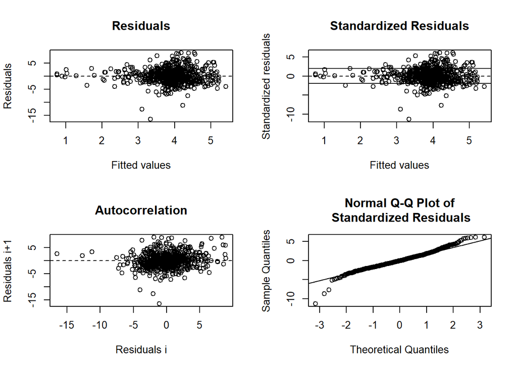

```
##
## ------
##  Shapiro-Wilk normality test
##
## data:  stdres
## W = 0.97385, p-value = 2.894e-09
##
##
## ------
```

```
##
##  Runs Test
##
## data:  as.factor(run)
## Standard Normal = -2.4534, p-value = 0.01415
## alternative hypothesis: two.sided
```

## predict and plot

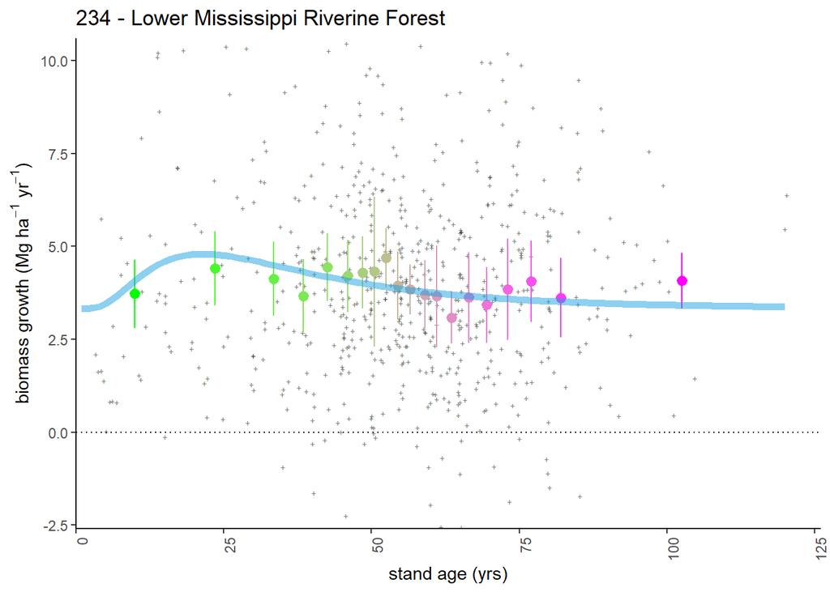

## plotting 2

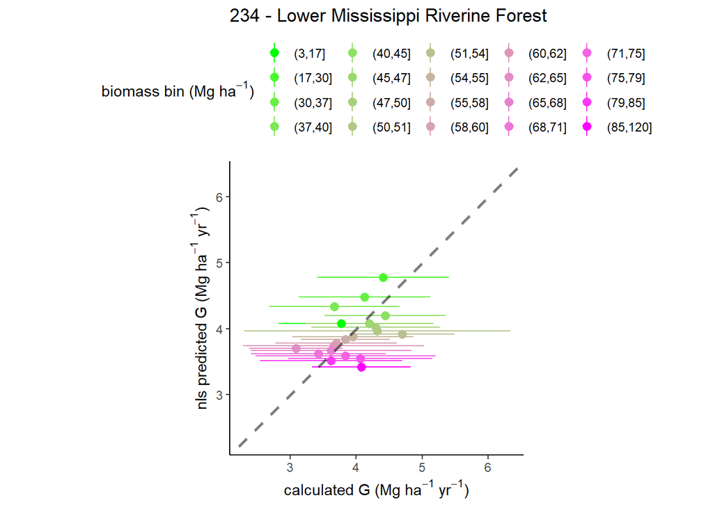

# 242 - Pacific Lowland Mixed Forest

## model selection 1

[output not shown]

```
## Error in h(simpleError(msg, call)) :
##   error in evaluating the argument 'object' in selecting a method for function 'summary': object 'nls_242.' not found
```

### summary

- simple model: does not fit
- phi model: does not fit
- phi-alpha model: does not fit

## plot residuals

```
## [1] "cannot plot residuals"
```

## predict and plot

```
## [1] "cannot plot data with prediction"
```

## plotting 2

# 251 - Prairie Parkland (Temperate)

## model selection 1

```
## Error in nls(fg2_1, data = G_251, start = c(ge = ge.start, a = a.start,  :
##   singular gradient
## Error in nls(fg2_2, data = G_251, start = c(ge = ge.start, phi = phi.start,  :
##   singular gradient
## Error in nls(fg2_3, data = G_251, start = c(ge = ge.start, phi = phi.start,  :
##   singular gradient
##   model AIC
## 1     1  NA
## 2     2  NA
## 3     3  NA
```

```
## Error in h(simpleError(msg, call)) :
##   error in evaluating the argument 'object' in selecting a method for function 'summary': object 'nls_251.' not found
```

### summary

- simple model: does not fit
- phi model: does not fit
- phi-alpha model: does not fit

## plot residuals

```
## [1] "cannot plot residuals"
```

## predict and plot

```
## [1] "cannot plot data with prediction"
```

## plotting 2

# 255 - Prairie Parkland (Subtropical)

## model selection 1

```
## Error in numericDeriv(form[[3L]], names(ind), env, central = nDcentral) :
##   Missing value or an infinity produced when evaluating the model
```

```
## Error in numericDeriv(form[[3L]], names(ind), env, central = nDcentral) :
##   Missing value or an infinity produced when evaluating the model
```

```
## Error in numericDeriv(form[[3L]], names(ind), env, central = nDcentral) :
##   Missing value or an infinity produced when evaluating the model
##   model AIC
## 1     1  NA
## 2     2  NA
## 3     3  NA
```

```
## Error in h(simpleError(msg, call)) :
##   error in evaluating the argument 'object' in selecting a method for function 'summary': object 'nls_255.' not found
```

### summary

- simple model: does not fit
- phi model: does not fit
- phi-alpha model: does not fit

## plot residuals

```
## [1] "cannot plot residuals"
```

## predict and plot

```
## [1] "cannot plot data with prediction"
```

## plotting 2

# 261 - California Coastal Chaparral Forest and Shrub

## model selection 1

### summary

- simple model: does not fit
- phi model: does not fit
- phi-alpha model: does not fit

## plot residuals

```
## [1] "cannot plot residuals"
```

## predict and plot

```
## [1] "cannot plot data with prediction"
```

## plotting 2

# 262 - California Dry Steppe

## model selection 1

### summary

- simple model: does not fit
- phi model: does not fit
- phi-alpha model: does not fit

## plot residuals

```
## [1] "cannot plot residuals"
```

## predict and plot

```
## [1] "cannot plot data with prediction"
```

## plotting 2

# 263 - California Coastal Steppe - Mixed Forest and Redwood Forest

## model selection 1

[output not shown]

```
## Error in h(simpleError(msg, call)) :
##   error in evaluating the argument 'object' in selecting a method for function 'summary': object 'nls_263.' not found
```

### summary

- simple model: does not fit
- phi model: does not fit
- phi-alpha model: does not fit

## plot residuals

```
## [1] "cannot plot residuals"
```

## predict and plot

```
## [1] "cannot plot data with prediction"
```

## plotting 2

# 313 - Colorado Plateau Semi-Desert

## model selection 1

[output not shown]

```
## Error in h(simpleError(msg, call)) :
##   error in evaluating the argument 'object' in selecting a method for function 'summary': object 'nls_313.' not found
```

### summary

- simple model: does not fit
- phi model: does not fit
- phi-alpha model: does not fit

## plot residuals

```
## [1] "cannot plot residuals"
```

## predict and plot

```
## [1] "cannot plot data with prediction"
```

## plotting 2

# 315 - Southwest Plateau and Plains Dry Steppe and Shrub

## model selection 1

[output not shown]

### summary

- simple model: does not fit
- phi model: does not fit
- phi-alpha model: does not fit

## plot residuals

```
## [1] "cannot plot residuals"
```

## predict and plot

```
## [1] "cannot plot data with prediction"
```

## plotting 2

# 321 - Chihuahuan Semi-Desert

## model selection 1

### summary

- simple model: does not fit
- phi model: does not fit
- phi-alpha model: does not fit

## plot residuals

```
## [1] "cannot plot residuals"
```

## predict and plot

```
## [1] "cannot plot data with prediction"
```

## plotting 2

# 322 - American Semidesert and Desert

## model selection 1

[output not shown]

```
## Error in h(simpleError(msg, call)) :
##   error in evaluating the argument 'object' in selecting a method for function 'summary': object 'nls_322.' not found
```

### summary

- simple model: does not fit
- phi model: does not fit
- phi-alpha model: does not fit

## plot residuals

```
## [1] "cannot plot residuals"
```

## predict and plot

```
## [1] "cannot plot data with prediction"
```

## plotting 2

# 331 - Great Plains/Palouse Dry Steppe

## model selection 1

[output not shown]

### summary

- simple model: does not fit
- phi model: does not fit
- phi-alpha model: does not fit

## plot residuals

```
## [1] "cannot plot residuals"
```

## predict and plot

```
## [1] "cannot plot data with prediction"
```

## plotting 2

# 332 - Great Plains Steppe

## model selection 1

### summary

- simple model: does not fit
- phi model: does not fit
- phi-alpha model: does not fit

## plot residuals

```
## [1] "cannot plot residuals"
```

## predict and plot

```
## [1] "cannot plot data with prediction"
```

## plotting 2

# 341 - Intermountain Semi-desert & Desert

## model selection 1

### summary

- simple model: does not fit
- phi model: does not fit
- phi-alpha model: does not fit

## plot residuals

```
## [1] "cannot plot residuals"
```

## predict and plot

```
## [1] "cannot plot data with prediction"
```

## plotting 2

# 342 - Intermountain Semi-Desert

## model selection 1

### summary

- simple model: does not fit
- phi model: does not fit
- phi-alpha model: does not fit

## plot residuals

```
## [1] "cannot plot residuals"
```

## predict and plot

```
## [1] "cannot plot data with prediction"
```

## plotting 2

# 411 - Everglades

## model selection 1

### summary

- simple model: does not fit
- phi model: does not fit
- phi-alpha model: does not fit

## plot residuals

```
## [1] "cannot plot residuals"
```

## predict and plot

```
## [1] "cannot plot data with prediction"
```

## plotting 2

# M211 - Adirondack-New England Mixed forest - Coniferous Forest - Alpine Meadow

## model selection 1

```
## Analysis of Variance Table
##
## Model 1: G_obs_TreeInc_MgHaYr ~ (1 + (MEASTIME_avg - 1990) * ge/100) * (a + b * exp(-((log(STDAGE_t1/c))/d)^2))
## Model 2: G_obs_TreeInc_MgHaYr ~ (1 + (MEASTIME_avg - 1990) * ge/100) * (1 + phi * DeltaPDSI) * (a + b * exp(-((log(STDAGE_t1/c))/d)^2))
## Model 3: G_obs_TreeInc_MgHaYr ~ (1 + (MEASTIME_avg - 1990) * ge/100) * (1 + phi * DeltaPDSI) * (1 - alpha * B_L_prop) * (a + b * exp(-((log(STDAGE_t1/c))/d)^2))
##   Res.Df Res.Sum Sq Df  Sum Sq F value    Pr(>F)
## 1   3942     2489.9
## 2   3941     2482.2  1  7.7445  12.296  0.000459 ***
## 3   3940     2452.7  1 29.5100  47.405 6.691e-12 ***
## ---
## Signif. codes:  0 '***' 0.001 '**' 0.01 '*' 0.05 '.' 0.1 ' ' 1
##   model      AIC
## 1     1 13883.84
## 2     2 13873.54
## 3     3 13828.34
```

```
##
## Formula: G_obs_TreeInc_MgHaYr ~ (1 + (MEASTIME_avg - 1990) * ge/100) *
##     (1 + phi * DeltaPDSI) * (1 - alpha * B_L_prop) * (a + b *
##     exp(-((log(STDAGE_t1/c))/d)^2))
##
## Parameters:
##        Estimate Std. Error t value Pr(>|t|)
## ge     1.299016   0.271162   4.791 1.72e-06 ***
## phi    0.016146   0.005204   3.103  0.00193 **
## alpha  0.563461   0.078682   7.161 9.49e-13 ***
## a      2.259469   0.138351  16.331  < 2e-16 ***
## b      0.634731   0.084323   7.527 6.38e-14 ***
## c     27.591165   2.278626  12.109  < 2e-16 ***
## d      0.895029   0.181083   4.943 8.03e-07 ***
## ---
## Signif. codes:  0 '***' 0.001 '**' 0.01 '*' 0.05 '.' 0.1 ' ' 1
##
## Residual standard error: 0.789 on 3940 degrees of freedom
##
## Number of iterations to convergence: 5
## Achieved convergence tolerance: 1.489e-06
##   (1 observation deleted due to missingness)
```

### summary

- simple model: fits
- phi model: fits
- phi-alpha model: fits

## plot residuals

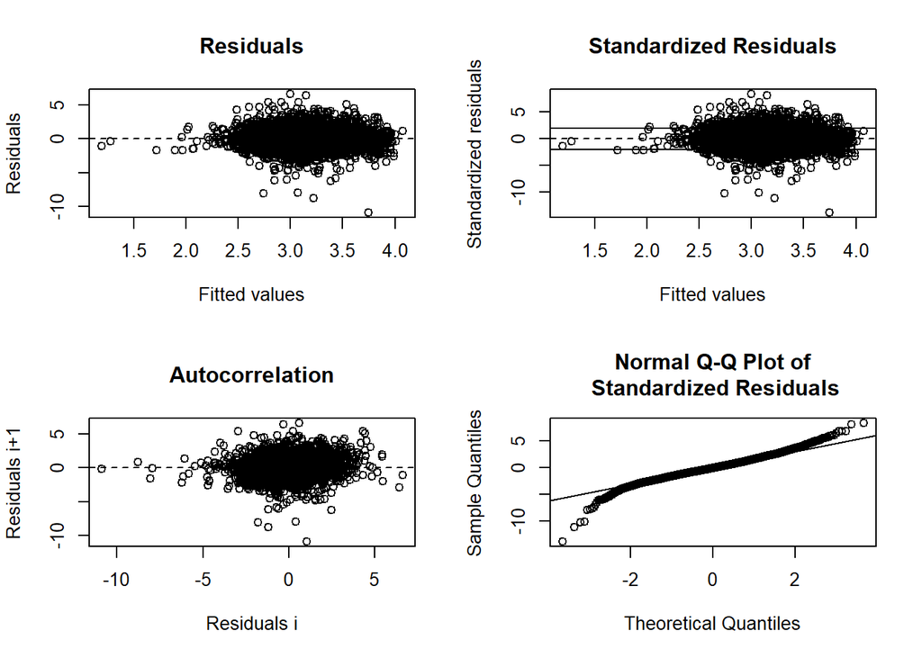

```
##
## ------
##  Shapiro-Wilk normality test
##
## data:  stdres
## W = 0.97857, p-value < 2.2e-16
##
##
## ------
```

```
##
##  Runs Test
##
## data:  as.factor(run)
## Standard Normal = -10.055, p-value < 2.2e-16
## alternative hypothesis: two.sided
```

## predict and plot

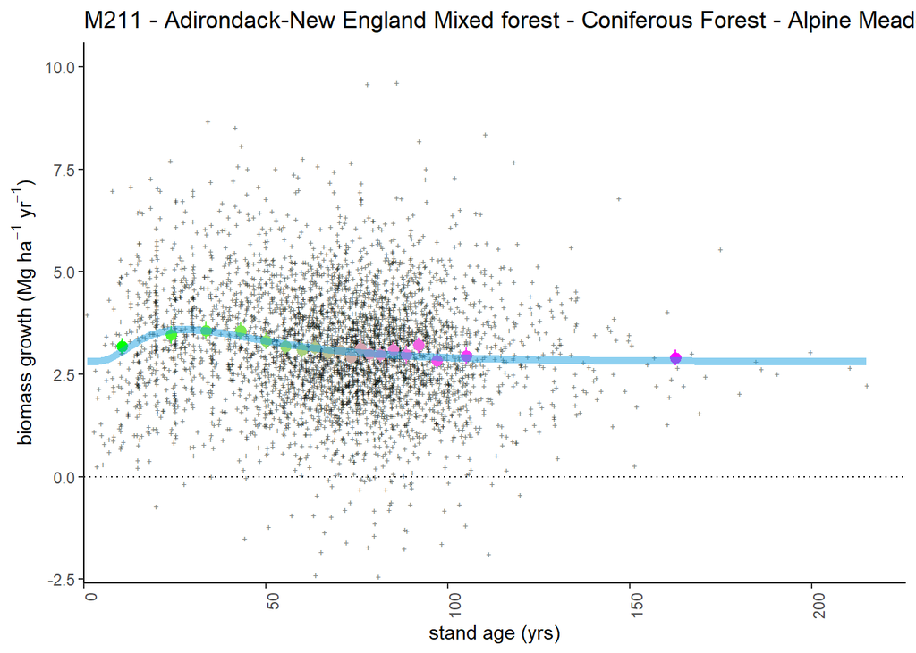

## plotting 2

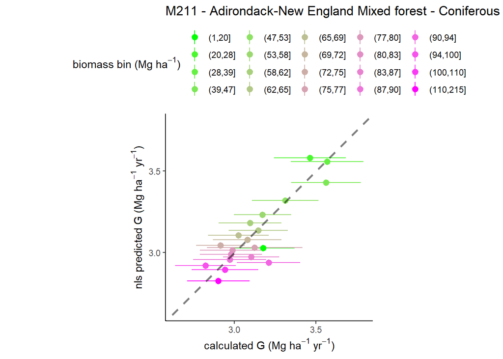